# PCA

```python
import pandas as pd
import numpy as np
from sklearn.decomposition import PCA
from sklearn.linear_model import LinearRegression
from sklearn.metrics import r2_score

import matplotlib.pyplot as plt
```

### Make the PCA of the factors in Multi-asset PCA CHANGES=4w.csv

```python
MA_pca_changes = pd.read_csv('Copie de Multi-asset PCA_CHANGES=4w.csv',index_col=0)
MA_pca_changes_normalised = (MA_pca_changes - MA_pca_changes.mean()) / MA_pca_changes.std()

pca_model = PCA()
pca = pca_model.fit_transform(MA_pca_changes_normalised)
```

```python
format_colour = lambda x: 'color:red' if x < 0. else 'color:lightgreen'
```

```python
loadings = pd.DataFrame(pca_model.components_, columns=MA_pca_changes_normalised.columns)
loadings.T.style.format(formatter='{:+.4f}').applymap(func=format_colour)
```

|  | 0 | 1 | 2 | 3 | 4 | 5 | 6 | 7 | 8 | 9 | 10 | 11 | 12 | 13 | 14 | 15 | 16 | 17 | 18 | 19 | 20 | 21 | 22 | 23 | 24 | 25 | 26 | 27 | 28 | … |
| --- | --- | --- | --- | --- | --- | --- | --- | --- | --- | --- | --- | --- | --- | --- | --- | --- | --- | --- | --- | --- | --- | --- | --- | --- | --- | --- | --- | --- | --- | --- |
| MSCI World | -0.2462 | +0.0481 | +0.0699 | -0.0231 | +0.0791 | +0.1157 | +0.1404 | -0.0494 | -0.0850 | +0.0081 | -0.0350 | +0.0060 | -0.1154 | +0.0513 | -0.1786 | -0.1197 | +0.1338 | -0.1336 | -0.0095 | +0.0031 | -0.0198 | -0.1874 | -0.1371 | +0.0134 | -0.0754 | -0.1517 | +0.0412 | -0.1099 | -0.0401 | … |
| S&P 500 | -0.2380 | +0.0504 | +0.0084 | -0.0260 | +0.0658 | +0.1531 | +0.1926 | -0.0559 | -0.0832 | +0.0482 | -0.0419 | +0.0031 | -0.0938 | +0.0868 | -0.2014 | -0.1448 | +0.1728 | -0.2238 | -0.0218 | +0.0532 | -0.1000 | -0.2790 | -0.1488 | +0.0176 | -0.1028 | -0.1932 | +0.0614 | -0.0208 | -0.0083 | … |
| Euro Stoxx 50 | -0.2313 | +0.0080 | -0.0185 | -0.0263 | +0.2232 | +0.0576 | +0.0357 | -0.0800 | -0.1254 | +0.0240 | -0.0317 | -0.0284 | -0.3380 | +0.0856 | -0.1572 | -0.0380 | +0.0249 | +0.2123 | +0.1986 | -0.0639 | +0.0961 | -0.0122 | -0.1060 | +0.1186 | -0.0270 | -0.1087 | -0.0404 | -0.2740 | -0.2352 | … |
| Euro Stoxx Banks | -0.2028 | -0.0478 | +0.0300 | +0.0307 | +0.2606 | -0.0605 | -0.1995 | -0.0922 | -0.1934 | -0.0151 | -0.0008 | -0.0133 | -0.3673 | +0.0666 | -0.1938 | +0.0356 | +0.1051 | +0.4407 | +0.0136 | -0.1735 | +0.0584 | +0.1487 | +0.2751 | -0.1190 | +0.1809 | +0.1158 | +0.0267 | +0.2241 | +0.1986 | … |
| CDX.IG 5Y | -0.2268 | +0.0132 | -0.0614 | +0.0019 | +0.2061 | +0.0422 | +0.1215 | +0.1169 | +0.1716 | +0.1234 | -0.0960 | -0.0617 | +0.1186 | -0.0483 | +0.1454 | +0.2411 | +0.2164 | -0.0135 | -0.1130 | +0.2099 | +0.0475 | -0.1992 | +0.2860 | +0.1914 | +0.1133 | -0.1177 | +0.0099 | -0.1415 | +0.2752 | … |
| CDX.HY 5Y | -0.2362 | +0.0350 | -0.0365 | -0.0534 | +0.1419 | +0.1175 | +0.0355 | +0.1464 | -0.0048 | -0.0312 | -0.0414 | +0.0235 | -0.0054 | +0.0293 | +0.2083 | -0.0418 | +0.1201 | -0.2908 | +0.1200 | -0.1123 | -0.1712 | +0.2440 | -0.0589 | -0.2431 | +0.0658 | -0.2484 | +0.2042 | +0.3573 | +0.3231 | … |
| iTraxx Europe 5Y | -0.2182 | -0.0144 | -0.0844 | -0.0610 | +0.2710 | -0.1312 | +0.0212 | +0.1153 | +0.1834 | +0.0619 | -0.0675 | -0.0307 | +0.0300 | +0.0192 | +0.2522 | +0.1853 | +0.0647 | +0.0012 | +0.0752 | +0.2282 | +0.2234 | -0.0578 | +0.1304 | +0.2746 | -0.0826 | +0.1605 | -0.0757 | -0.0107 | -0.1113 | … |
| iTraxx Crossover 5Y | -0.2279 | -0.0034 | -0.0723 | -0.1239 | +0.1645 | -0.0209 | -0.0067 | +0.1312 | +0.0568 | -0.0655 | -0.0429 | +0.0617 | -0.0617 | +0.0092 | +0.3163 | +0.0367 | -0.0885 | -0.1706 | +0.2268 | -0.0425 | +0.2144 | +0.3701 | -0.2377 | -0.1653 | +0.0119 | +0.1425 | -0.0910 | +0.0218 | -0.3174 | … |
| Italy - Germany 10Y | +0.0866 | +0.0277 | -0.0483 | +0.0418 | -0.3536 | +0.5283 | +0.1537 | +0.3964 | -0.1243 | -0.1593 | -0.0793 | -0.0318 | -0.1467 | +0.0765 | +0.0406 | +0.0229 | +0.2363 | +0.2043 | -0.0396 | +0.1611 | +0.3457 | +0.0147 | +0.0060 | -0.0587 | -0.0959 | +0.0257 | -0.0078 | +0.1404 | -0.0926 | … |
| US 2Y | -0.1027 | -0.2476 | -0.1634 | +0.1108 | -0.0440 | +0.1254 | -0.0283 | +0.0520 | +0.1978 | -0.0387 | +0.0433 | -0.0963 | -0.1059 | -0.4250 | -0.0369 | -0.3334 | -0.0534 | -0.0513 | -0.0743 | +0.0307 | +0.0078 | +0.0148 | +0.2616 | +0.0787 | +0.2994 | -0.0185 | +0.2665 | +0.0543 | -0.2259 | … |
| US 5Y | -0.1008 | -0.2991 | -0.1159 | +0.0247 | +0.0136 | +0.1059 | +0.0181 | -0.0036 | +0.1367 | -0.1543 | +0.0879 | -0.1223 | +0.0319 | -0.1421 | -0.0199 | -0.1880 | -0.0177 | -0.0149 | -0.0820 | -0.0963 | -0.0786 | -0.0234 | +0.0762 | +0.0065 | -0.0500 | +0.0163 | -0.0587 | -0.0393 | -0.1596 | … |
| US 10Y | -0.0879 | -0.3139 | -0.0745 | -0.0409 | +0.0362 | +0.0435 | -0.0270 | -0.0559 | +0.1374 | -0.1843 | +0.0160 | -0.1374 | +0.0717 | +0.0877 | +0.0295 | -0.0451 | +0.0220 | +0.0369 | -0.0943 | -0.1258 | +0.0040 | -0.0349 | -0.1359 | -0.0630 | -0.2304 | -0.0003 | -0.0918 | -0.1157 | +0.1030 | … |
| Germany 2Y | -0.1017 | -0.2275 | +0.1410 | +0.1666 | -0.0528 | -0.1254 | -0.0124 | +0.2859 | -0.1758 | +0.1535 | +0.0955 | +0.1455 | -0.1083 | -0.2749 | -0.0576 | -0.0970 | -0.2621 | +0.0258 | +0.1749 | +0.3948 | +0.0687 | -0.0336 | -0.1597 | -0.1601 | +0.0609 | -0.0572 | -0.2106 | -0.1699 | +0.3156 | … |
| Germany 5Y | -0.0887 | -0.2820 | +0.1383 | +0.1569 | +0.0217 | -0.1344 | +0.0157 | +0.2213 | -0.0916 | +0.1140 | +0.0441 | +0.0906 | -0.0017 | -0.0378 | -0.0902 | +0.0515 | -0.1058 | -0.0119 | +0.1100 | +0.1221 | -0.1256 | -0.0278 | -0.0240 | -0.0046 | -0.1823 | -0.0405 | +0.1945 | +0.1636 | -0.1557 | … |
| Germany 10Y | -0.0768 | -0.3079 | +0.0957 | +0.0901 | +0.0450 | -0.0991 | -0.0036 | +0.1570 | -0.0250 | +0.0675 | -0.0417 | +0.0308 | +0.0778 | +0.1328 | -0.0663 | +0.1773 | -0.0069 | +0.0406 | -0.0027 | -0.1873 | -0.1965 | -0.0839 | -0.0948 | +0.1380 | -0.2727 | +0.0586 | +0.1430 | +0.1890 | -0.1831 | … |
| US B/E Inflation 10Y | -0.1784 | -0.0880 | +0.1131 | -0.0775 | -0.0592 | +0.1836 | -0.1816 | -0.1481 | +0.1752 | -0.0276 | -0.0100 | -0.0613 | +0.4461 | +0.2336 | -0.4846 | +0.0757 | -0.0415 | +0.0452 | +0.1849 | +0.3333 | +0.1007 | +0.2877 | -0.0167 | +0.0763 | +0.1581 | -0.1184 | -0.0462 | +0.1332 | -0.0569 | … |
| Dollar Index | +0.1173 | -0.0831 | -0.4418 | -0.0700 | -0.0351 | +0.1554 | -0.0627 | -0.0139 | +0.0326 | +0.1894 | +0.0997 | +0.1227 | -0.0894 | +0.0694 | +0.0130 | +0.1342 | -0.0893 | +0.0554 | +0.2126 | +0.0270 | -0.1688 | -0.0040 | -0.0632 | +0.1367 | +0.1062 | -0.0538 | -0.0163 | -0.0359 | +0.0799 | … |
| EUR/USD | -0.1074 | +0.0546 | +0.4420 | +0.1229 | +0.0478 | -0.1995 | +0.1168 | -0.0382 | -0.0852 | -0.1226 | -0.0812 | -0.0490 | +0.1353 | -0.0735 | -0.0135 | -0.1419 | +0.1123 | -0.1012 | -0.2329 | +0.0061 | +0.2373 | +0.0929 | +0.1031 | -0.0631 | +0.0043 | +0.0932 | -0.0104 | +0.0353 | -0.0422 | … |
| USD/JPY | -0.0397 | -0.2004 | -0.2603 | +0.0095 | -0.0410 | -0.0055 | +0.0836 | -0.2803 | -0.2104 | +0.3573 | +0.2295 | +0.4003 | +0.1562 | -0.1188 | -0.0932 | +0.0183 | +0.2156 | -0.1718 | -0.1451 | -0.1488 | +0.4456 | +0.0652 | -0.0074 | +0.0070 | -0.0678 | +0.0670 | +0.0288 | +0.1073 | +0.0178 | … |
| Precious Metals | -0.0684 | +0.0947 | +0.3483 | -0.0446 | -0.1058 | +0.1599 | +0.1181 | -0.0376 | +0.5486 | +0.0188 | +0.2149 | +0.2144 | -0.1187 | -0.1645 | -0.0732 | +0.1799 | -0.1589 | +0.0577 | +0.2816 | -0.3363 | +0.1995 | -0.2205 | +0.0366 | -0.0624 | -0.0630 | -0.0204 | -0.0020 | +0.0699 | +0.0917 | … |
| Industrial Metals | -0.1587 | -0.0268 | +0.1972 | -0.0902 | -0.1828 | +0.0932 | -0.2673 | -0.1529 | +0.2000 | -0.0031 | +0.1068 | +0.3856 | -0.3871 | +0.2191 | +0.1634 | -0.0482 | -0.0420 | -0.1057 | -0.4115 | +0.2855 | -0.1601 | +0.1610 | -0.0117 | +0.1614 | -0.0441 | +0.0617 | +0.0614 | -0.0404 | -0.0026 | … |
| Crude Oil | -0.1265 | -0.0715 | +0.1421 | -0.0788 | -0.1176 | +0.1991 | -0.3744 | -0.2711 | -0.3213 | -0.2548 | -0.3397 | +0.1603 | +0.1230 | -0.4100 | +0.2083 | +0.2021 | +0.0439 | +0.0018 | +0.1751 | -0.0487 | -0.0314 | -0.1773 | -0.0758 | +0.1578 | +0.0137 | -0.0469 | -0.0002 | -0.0161 | -0.0090 | … |
| Agriculture | -0.0817 | -0.0648 | +0.2565 | -0.0575 | -0.2567 | +0.1261 | -0.2225 | -0.0884 | -0.0892 | +0.5839 | +0.0976 | -0.5158 | -0.0438 | +0.1021 | +0.2528 | -0.1325 | +0.0698 | -0.0850 | +0.1633 | -0.0924 | +0.0295 | -0.0138 | +0.0540 | +0.0536 | +0.0023 | +0.0650 | -0.0026 | -0.0141 | -0.0074 | … |
| S&P 500 1M ATM imp. vol. | +0.2183 | -0.0260 | +0.0429 | -0.0724 | +0.0563 | -0.1219 | -0.3554 | +0.2309 | -0.0040 | -0.0517 | +0.1291 | +0.0412 | -0.0232 | -0.0224 | +0.0009 | -0.0051 | +0.1307 | -0.0270 | +0.0215 | -0.0918 | +0.1590 | +0.1606 | +0.2697 | +0.1128 | -0.3262 | -0.6116 | +0.0508 | -0.1038 | -0.0428 | … |
| S&P 500 1M 80% imp. vol. | +0.1904 | -0.0242 | +0.0455 | -0.0892 | +0.1256 | -0.0678 | -0.3724 | +0.3018 | +0.0487 | -0.1556 | +0.1330 | +0.0106 | -0.1015 | +0.0508 | -0.2469 | -0.0872 | +0.3374 | -0.3858 | +0.1339 | -0.0819 | +0.0874 | -0.1876 | -0.1632 | +0.1391 | +0.2555 | +0.3137 | -0.0630 | -0.0408 | +0.0772 | … |
| EUR/USD 3M ATM vol. | +0.1734 | +0.0150 | +0.0789 | +0.0957 | +0.2956 | +0.4230 | +0.0065 | -0.0397 | -0.0231 | +0.1334 | -0.1168 | +0.0577 | -0.0364 | -0.1425 | -0.1710 | +0.0891 | -0.0021 | -0.2742 | +0.0684 | +0.0397 | -0.2425 | +0.2279 | +0.3480 | -0.1839 | -0.2947 | +0.2545 | -0.1779 | -0.1791 | -0.0392 | … |
| USD/JPY 3M ATM vol. | +0.1573 | -0.0307 | +0.1925 | -0.0288 | +0.2853 | +0.1632 | +0.0369 | +0.0070 | +0.0582 | +0.0884 | +0.1112 | +0.3157 | +0.2991 | +0.0547 | +0.2704 | -0.4976 | +0.2643 | +0.3902 | +0.1534 | +0.0356 | -0.1460 | -0.0198 | -0.0891 | +0.0457 | +0.0317 | +0.0183 | -0.0297 | -0.0378 | -0.0078 | … |
| AUD/USD 3M ATM vol. | +0.2029 | -0.0491 | +0.0232 | +0.0625 | +0.3088 | +0.1407 | -0.2537 | -0.0147 | +0.0342 | +0.1337 | -0.0983 | +0.0085 | +0.0167 | +0.1307 | +0.0576 | +0.1195 | -0.1620 | +0.0304 | -0.1435 | +0.1823 | +0.1471 | -0.4083 | -0.0490 | -0.3240 | +0.0564 | +0.0321 | +0.3027 | +0.2119 | -0.1887 | … |
| USD/CAD 3M ATM vol. | +0.1863 | +0.0114 | +0.1230 | +0.0466 | +0.3211 | +0.2649 | +0.0422 | +0.0547 | -0.0416 | +0.1179 | -0.1444 | -0.0885 | -0.0243 | -0.0405 | -0.0180 | -0.0505 | -0.4053 | -0.0667 | -0.2806 | -0.1964 | +0.2281 | +0.1630 | -0.2738 | +0.3430 | +0.1708 | -0.1950 | -0.0107 | -0.0122 | +0.1246 | … |
| USD 2Y x 2Y ATM vol. | +0.0583 | -0.2131 | +0.0549 | -0.3751 | +0.0208 | -0.0024 | +0.1661 | -0.0236 | -0.1951 | -0.1103 | -0.0047 | +0.0833 | -0.0576 | +0.2175 | +0.0704 | -0.1627 | -0.2630 | -0.1685 | +0.0677 | +0.0052 | +0.0213 | -0.2428 | +0.3669 | +0.0724 | +0.0930 | -0.0925 | -0.4371 | +0.3277 | -0.0625 | … |
| USD 3M x 10Y ATM vol. | +0.1408 | -0.1267 | +0.1810 | -0.2204 | +0.1474 | +0.0721 | +0.1664 | -0.0918 | -0.0898 | -0.0716 | +0.4349 | -0.2048 | -0.0588 | -0.2606 | +0.0257 | +0.3273 | +0.1807 | +0.0490 | -0.1218 | +0.1575 | -0.1226 | +0.0761 | -0.1006 | -0.0479 | +0.0705 | -0.0340 | -0.0194 | +0.0930 | +0.0171 | … |
| USD 1Y x 10Y ATM vol. | +0.1254 | -0.1752 | +0.1173 | -0.3722 | +0.0515 | +0.0104 | +0.1894 | -0.0224 | -0.0979 | -0.0797 | +0.1565 | -0.0834 | -0.0665 | -0.0385 | +0.0124 | +0.1438 | +0.0447 | +0.0506 | -0.0087 | +0.0849 | -0.0369 | +0.0871 | -0.1457 | +0.0900 | +0.0455 | +0.0283 | +0.2022 | -0.0666 | -0.0741 | … |
| USD 5Y x 5Y ATM vol. | +0.0914 | -0.1691 | +0.0545 | -0.4311 | -0.0684 | -0.0642 | +0.1189 | +0.0045 | -0.0355 | +0.0014 | -0.2433 | +0.0783 | +0.0204 | +0.1185 | -0.0457 | -0.0818 | -0.1072 | -0.0343 | +0.1249 | +0.0054 | +0.1567 | +0.0409 | +0.1787 | -0.1827 | +0.0069 | +0.1027 | +0.4810 | -0.3820 | +0.1723 | … |
| USD 10Y x 20Y ATM vol. | +0.1045 | -0.0776 | -0.0034 | -0.3555 | -0.0652 | -0.1607 | -0.0027 | +0.0907 | +0.2711 | +0.3281 | -0.5076 | +0.0256 | -0.1209 | -0.2704 | -0.1805 | -0.0323 | +0.2297 | +0.1335 | -0.1680 | -0.0005 | -0.0828 | +0.0620 | -0.1773 | -0.0912 | -0.0288 | -0.0622 | -0.2398 | +0.1868 | -0.0552 | … |
| US Govt. | +0.0879 | +0.3127 | +0.0952 | +0.0058 | -0.0234 | -0.0767 | +0.0680 | +0.0726 | -0.1549 | +0.1645 | +0.0354 | +0.1569 | -0.0575 | -0.0380 | -0.0387 | +0.0744 | +0.0119 | -0.0436 | +0.0719 | +0.0909 | -0.0252 | -0.0134 | +0.0815 | +0.0403 | +0.0536 | -0.0728 | +0.0339 | +0.0629 | -0.2262 | … |
| European Govt. | +0.0062 | +0.2943 | -0.1234 | -0.1681 | +0.1004 | -0.0935 | -0.0924 | -0.2247 | +0.0665 | -0.0236 | +0.1420 | -0.1160 | -0.0503 | -0.1942 | -0.0207 | -0.1731 | -0.0490 | -0.0480 | +0.0886 | +0.2305 | +0.0704 | -0.0640 | -0.0311 | -0.1991 | -0.0668 | -0.1754 | +0.0299 | +0.0356 | -0.2156 | … |
| US Corp. Bonds | -0.1239 | +0.2569 | +0.0374 | -0.1653 | -0.0555 | +0.0069 | +0.0894 | +0.2577 | -0.1323 | +0.0871 | +0.0375 | +0.1064 | +0.1246 | -0.1384 | -0.1251 | -0.0243 | -0.1091 | +0.0332 | +0.0122 | -0.1111 | -0.1964 | +0.0788 | +0.1127 | +0.3247 | +0.0875 | +0.1586 | +0.2064 | +0.0636 | -0.1406 | … |
| European Corp. Bonds | -0.1265 | +0.2194 | -0.1431 | -0.2517 | +0.0633 | +0.0634 | -0.1485 | +0.0554 | -0.0429 | -0.0475 | +0.1101 | -0.1149 | +0.0605 | -0.1521 | -0.0821 | -0.2125 | -0.1866 | +0.0894 | -0.0513 | +0.1038 | +0.0662 | -0.0695 | -0.0670 | +0.1288 | -0.4597 | +0.2405 | +0.0993 | +0.2604 | +0.3153 | … |
| US High Yield | -0.2248 | +0.0745 | -0.0217 | -0.1552 | -0.0544 | +0.1087 | -0.1225 | +0.2107 | -0.0493 | +0.0606 | +0.1003 | +0.0980 | +0.2019 | +0.0377 | +0.0087 | +0.1071 | -0.0296 | +0.0277 | -0.2101 | -0.1774 | -0.1411 | -0.0930 | +0.0153 | -0.2863 | +0.2705 | -0.1289 | -0.0638 | -0.1131 | -0.0828 | … |
| European High Yield | -0.2180 | +0.0504 | -0.0288 | -0.2007 | +0.0352 | +0.0555 | -0.1760 | +0.2252 | -0.0952 | +0.0674 | +0.1774 | -0.0052 | +0.1675 | -0.0319 | -0.0449 | +0.0434 | -0.1260 | +0.1234 | -0.2834 | -0.1313 | +0.0212 | -0.0612 | +0.0164 | -0.1868 | -0.0748 | +0.0724 | -0.1817 | -0.2530 | -0.1022 | … |

### Display the fraction of the variance explained by each PCA (sorted by the explained variance) and the cumsum

```python
explained_variance = pca_model.explained_variance_ratio_
print("Explained variance by each PCA:\n", explained_variance)
```

```
Explained variance by each PCA:
 [3.49501109e-01 1.96122521e-01 7.86152054e-02 6.73511749e-02
 4.43169362e-02 3.20005210e-02 2.57346311e-02 2.35850404e-02
 1.91035916e-02 1.75077524e-02 1.63124328e-02 1.43136043e-02
 1.30765640e-02 1.28271959e-02 1.14520977e-02 1.06077293e-02
 9.00256480e-03 7.81254429e-03 7.54358004e-03 6.57798052e-03
 6.31120925e-03 4.57440808e-03 3.91695351e-03 3.21596951e-03
 2.90392285e-03 2.64747045e-03 2.28898300e-03 2.09169976e-03
 1.62305334e-03 1.43251415e-03 1.28479662e-03 9.74741109e-04
 9.36963577e-04 6.06778001e-04 5.77747898e-04 4.10306847e-04
 3.41867587e-04 2.08664913e-04 1.77448809e-04 1.09724080e-04]
```

```python
cumulative_explained_variance = np.cumsum(explained_variance)
print("Cumulative explained variance:\n", cumulative_explained_variance)
```

```
Cumulative explained variance:
 [0.34950111 0.54562363 0.62423884 0.69159001 0.73590695 0.76790747
 0.7936421  0.81722714 0.83633073 0.85383848 0.87015092 0.88446452
 0.89754108 0.91036828 0.92182038 0.93242811 0.94143067 0.94924322
 0.9567868  0.96336478 0.96967599 0.97425039 0.97816735 0.98138332
 0.98428724 0.98693471 0.98922369 0.99131539 0.99293845 0.99437096
 0.99565576 0.9966305  0.99756746 0.99817424 0.99875199 0.99916229
 0.99950416 0.99971283 0.99989028 1.        ]
```

### How many components are needed to explain 75% of the variance? 80%?

```python
components_75 = np.where(cumulative_explained_variance >= 0.75)[0][0] + 1
components_80 = np.where(cumulative_explained_variance >= 0.80)[0][0] + 1
print(f"{components_75} components are needed to explain 75% of the variance.")
print(f"{components_80} components are needed to explain 80% of the variance.")
```

```
6 components are needed to explain 75% of the variance.
8 components are needed to explain 80% of the variance.
```

### Display the cumsum of the returns of the 3 main components

```python
returns_PCA = pd.DataFrame(pca_model.transform(MA_pca_changes_normalised), columns=[f'PC{i+1}' for i in range(pca_model.n_components_)])
print("Cumulative returns of the 3 main components:\n", returns_PCA.iloc[:, :3].cumsum())
```

```
Cumulative returns of the 3 main components:
               PC1           PC2           PC3
0   -1.131291e+00  1.568731e+00 -2.907101e+00
1   -1.403827e+00  5.595963e-01 -3.419135e+00
2   -3.661723e+00 -7.017453e-01 -2.199867e+00
3   -2.515865e+00  1.695328e+00 -2.465353e+00
4   -3.144404e+00 -4.732644e-01 -3.541697e+00
..            ...           ...           ...
227  9.513089e-01 -1.909830e-01 -3.130401e+00
228  1.275235e+00 -4.889290e+00 -6.175842e-01
229 -2.620088e+00  2.275565e+00 -1.812545e-01
230 -2.463381e+00 -4.476623e+00 -1.842578e+00
231 -1.287859e-14 -2.131628e-14  1.265654e-14

[232 rows x 3 columns]
```

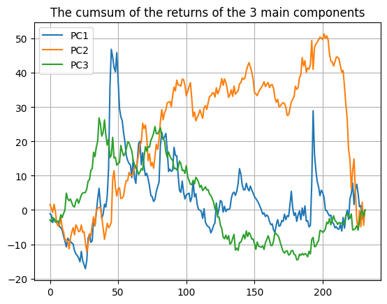

```python
plt.plot(returns_PCA.iloc[:, :3].cumsum())
leg = ['PC1','PC2','PC3']
plt.grid(True)
plt.legend(leg,loc='best')
plt.title('The cumsum of the returns of the 3 main components')
plt.show()
```

```python
r2_df = pd.DataFrame(index=MA_pca_changes_normalised.columns, columns=[f'PC{i+1}' for i in range(pca_model.n_components_)])
for factor in MA_pca_changes_normalised.columns:
    for pc in r2_df.columns:
        model = LinearRegression().fit(returns_PCA[[pc]], MA_pca_changes_normalised[factor])
        predictions = model.predict(returns_PCA[[pc]])
        r2_df.loc[factor, pc] = r2_score(MA_pca_changes_normalised[factor], predictions)

r2_df = r2_df.apply(pd.to_numeric, errors='coerce')

r2_df
```

|  | PC1 | PC2 | PC3 | PC4 | PC5 | PC6 | PC7 | PC8 | PC9 | PC10 | ... | PC31 | PC32 | PC33 | PC34 | PC35 | PC36 | PC37 | PC38 | PC39 | PC40 |
| --- | --- | --- | --- | --- | --- | --- | --- | --- | --- | --- | --- | --- | --- | --- | --- | --- | --- | --- | --- | --- | --- |
| MSCI World | 0.847734 | 0.018132 | 0.015373 | 0.001434 | 0.011094 | 0.017129 | 0.020302 | 0.002302 | 0.005526 | 0.000046 | ... | 1.394304e-04 | 0.000383 | 7.412961e-04 | 2.315037e-06 | 1.166508e-05 | 7.177734e-06 | 4.824729e-05 | 1.499622e-04 | 1.714606e-03 | 1.679936e-03 |
| S&P 500 | 0.791634 | 0.019967 | 0.000220 | 0.001818 | 0.007687 | 0.030013 | 0.038203 | 0.002953 | 0.005294 | 0.001627 | ... | 9.739845e-04 | 0.002920 | 3.898036e-03 | 1.056651e-04 | 4.946021e-07 | 3.042047e-04 | 1.041146e-04 | 1.138904e-04 | 8.276297e-04 | 7.592666e-04 |
| Euro Stoxx 50 | 0.747764 | 0.000497 | 0.001075 | 0.001861 | 0.088351 | 0.004250 | 0.001310 | 0.006042 | 0.012026 | 0.000402 | ... | 4.513669e-05 | 0.010648 | 3.401533e-03 | 1.312014e-04 | 1.760149e-05 | 4.668580e-04 | 1.257337e-04 | 8.985179e-06 | 1.480830e-04 | 6.991832e-05 |
| Euro Stoxx Banks | 0.574965 | 0.017899 | 0.002831 | 0.002532 | 0.120362 | 0.004685 | 0.040990 | 0.008019 | 0.028593 | 0.000160 | ... | 2.532844e-05 | 0.003260 | 5.726346e-04 | 6.056276e-05 | 8.075925e-06 | 8.139154e-05 | 7.407117e-05 | 1.815264e-05 | 7.749820e-06 | 2.940043e-07 |
| CDX.IG 5Y | 0.719317 | 0.001376 | 0.011846 | 0.000010 | 0.075298 | 0.002283 | 0.015204 | 0.012887 | 0.022499 | 0.010672 | ... | 1.984130e-03 | 0.000307 | 8.923371e-04 | 5.266626e-03 | 4.791749e-04 | 1.389138e-05 | 3.406397e-07 | 3.546004e-06 | 4.276767e-08 | 3.142745e-08 |
| CDX.HY 5Y | 0.779932 | 0.009609 | 0.004181 | 0.007669 | 0.035685 | 0.017670 | 0.001295 | 0.020226 | 0.000017 | 0.000680 | ... | 5.322577e-05 | 0.000842 | 2.278346e-03 | 2.257205e-03 | 5.731757e-04 | 4.527142e-05 | 3.935893e-06 | 3.402826e-05 | 6.281247e-07 | 7.726994e-07 |
| iTraxx Europe 5Y | 0.665570 | 0.001616 | 0.022407 | 0.010025 | 0.130195 | 0.022045 | 0.000462 | 0.012546 | 0.025701 | 0.002686 | ... | 5.107135e-04 | 0.001387 | 4.848371e-04 | 8.090210e-03 | 8.913355e-04 | 2.933857e-06 | 1.689305e-05 | 1.442518e-05 | 3.252383e-06 | 1.235945e-06 |
| iTraxx Crossover 5Y | 0.726087 | 0.000088 | 0.016429 | 0.041374 | 0.047959 | 0.000557 | 0.000046 | 0.016236 | 0.002467 | 0.003005 | ... | 2.302162e-04 | 0.000051 | 2.011978e-03 | 5.119459e-03 | 2.828740e-05 | 2.826573e-07 | 1.481080e-05 | 3.170652e-05 | 5.580187e-06 | 1.577823e-07 |
| Italy - Germany 10Y | 0.104820 | 0.006027 | 0.007327 | 0.004699 | 0.221695 | 0.357315 | 0.024310 | 0.148270 | 0.011815 | 0.017771 | ... | 4.081448e-04 | 0.000005 | 6.277003e-05 | 5.704296e-05 | 2.503307e-05 | 1.093889e-04 | 1.636511e-06 | 1.604535e-06 | 1.326736e-05 | 4.543910e-06 |
| US 2Y | 0.147492 | 0.480846 | 0.083955 | 0.033085 | 0.003437 | 0.020123 | 0.000822 | 0.002547 | 0.029883 | 0.001047 | ... | 1.857329e-04 | 0.000149 | 8.008987e-06 | 2.472703e-05 | 6.453954e-04 | 1.397188e-04 | 7.303063e-08 | 4.028535e-04 | 2.666402e-05 | 4.523572e-09 |
| US 5Y | 0.142163 | 0.702009 | 0.042211 | 0.001648 | 0.000329 | 0.014355 | 0.000339 | 0.000012 | 0.014270 | 0.016671 | ... | 5.174223e-04 | 0.000080 | 5.993061e-05 | 2.022530e-04 | 3.307888e-03 | 1.551276e-03 | 2.009111e-03 | 1.209380e-03 | 2.873112e-05 | 1.538642e-07 |
| US 10Y | 0.108046 | 0.772846 | 0.017462 | 0.004516 | 0.002325 | 0.002426 | 0.000752 | 0.002944 | 0.014428 | 0.023798 | ... | 1.525722e-03 | 0.000002 | 1.096507e-03 | 1.835349e-04 | 5.615121e-05 | 2.007559e-04 | 8.773102e-05 | 3.786538e-03 | 2.475545e-04 | 8.041316e-08 |
| Germany 2Y | 0.144694 | 0.405909 | 0.062542 | 0.074811 | 0.004935 | 0.020125 | 0.000158 | 0.077126 | 0.023609 | 0.016491 | ... | 2.023091e-03 | 0.000021 | 4.692975e-04 | 5.225805e-07 | 8.138203e-05 | 3.087371e-04 | 4.395180e-04 | 1.671912e-05 | 7.620886e-06 | 1.176344e-06 |
| Germany 5Y | 0.109984 | 0.623796 | 0.060162 | 0.066282 | 0.000839 | 0.023122 | 0.000255 | 0.046191 | 0.006415 | 0.009098 | ... | 6.596695e-03 | 0.000423 | 6.830375e-04 | 6.506486e-05 | 3.619223e-04 | 1.802378e-03 | 3.450237e-03 | 6.556202e-05 | 2.273219e-05 | 2.053951e-06 |
| Germany 10Y | 0.082478 | 0.743492 | 0.028793 | 0.021847 | 0.003587 | 0.012570 | 0.000013 | 0.023242 | 0.000478 | 0.003189 | ... | 2.290077e-03 | 0.000581 | 5.315351e-04 | 3.960534e-04 | 1.836351e-03 | 2.274413e-03 | 2.299631e-03 | 7.239440e-05 | 2.816437e-05 | 4.990026e-05 |
| US B/E Inflation 10Y | 0.444796 | 0.060727 | 0.040191 | 0.016170 | 0.006221 | 0.043129 | 0.033947 | 0.020694 | 0.023457 | 0.000532 | ... | 1.039991e-06 | 0.000033 | 1.503066e-06 | 2.167960e-07 | 3.764831e-05 | 8.289464e-07 | 3.784045e-05 | 2.941205e-07 | 1.029503e-05 | 2.007636e-06 |
| Dollar Index | 0.192258 | 0.054140 | 0.613654 | 0.013217 | 0.002187 | 0.030921 | 0.004048 | 0.000184 | 0.000814 | 0.025112 | ... | 1.493496e-04 | 0.000045 | 4.709481e-04 | 3.409650e-05 | 3.469682e-04 | 9.030463e-06 | 5.568086e-06 | 2.565474e-04 | 1.549314e-03 | 1.068679e-03 |
| EUR/USD | 0.161131 | 0.023387 | 0.614468 | 0.040719 | 0.004057 | 0.050950 | 0.014046 | 0.001373 | 0.005543 | 0.010528 | ... | 6.909131e-04 | 0.000180 | 1.542289e-04 | 1.678366e-05 | 5.432683e-05 | 1.873921e-05 | 2.804466e-06 | 1.864379e-04 | 1.912678e-03 | 6.823797e-04 |
| USD/JPY | 0.022078 | 0.314967 | 0.213099 | 0.000244 | 0.002974 | 0.000039 | 0.007198 | 0.074115 | 0.033816 | 0.089404 | ... | 1.202827e-05 | 0.000045 | 3.726493e-04 | 1.631329e-06 | 1.128994e-05 | 8.185923e-07 | 1.465464e-05 | 1.702933e-05 | 2.648254e-05 | 2.117395e-05 |
| Precious Metals | 0.065329 | 0.070289 | 0.381549 | 0.005353 | 0.019842 | 0.032732 | 0.014369 | 0.001332 | 0.229951 | 0.000248 | ... | 2.175811e-09 | 0.000089 | 9.465059e-06 | 2.061354e-06 | 2.468023e-05 | 8.787420e-08 | 1.331583e-06 | 1.266196e-07 | 1.450599e-05 | 2.264857e-07 |
| Industrial Metals | 0.352014 | 0.005616 | 0.122303 | 0.021939 | 0.059225 | 0.011116 | 0.073523 | 0.022048 | 0.030557 | 0.000007 | ... | 3.909757e-05 | 0.000109 | 2.340625e-05 | 1.622079e-08 | 2.089187e-06 | 9.306412e-06 | 6.566243e-07 | 2.912029e-06 | 2.911681e-07 | 7.167190e-07 |
| Crude Oil | 0.223810 | 0.040065 | 0.063522 | 0.016739 | 0.024498 | 0.050765 | 0.144306 | 0.069322 | 0.078905 | 0.045454 | ... | 1.312605e-04 | 0.000032 | 2.211225e-05 | 2.683665e-05 | 4.235888e-05 | 1.001845e-06 | 1.030635e-08 | 2.609670e-06 | 3.024436e-06 | 9.022983e-08 |
| Agriculture | 0.093311 | 0.032897 | 0.206967 | 0.008900 | 0.116779 | 0.020360 | 0.050957 | 0.007366 | 0.006077 | 0.238740 | ... | 3.129577e-05 | 0.000024 | 2.117514e-06 | 3.335491e-06 | 1.493119e-06 | 2.417824e-06 | 1.518438e-07 | 9.424290e-07 | 3.111117e-07 | 8.371019e-08 |
| S&P 500 1M ATM imp. vol. | 0.666423 | 0.005311 | 0.005788 | 0.014132 | 0.005610 | 0.019025 | 0.130001 | 0.050288 | 0.000012 | 0.001873 | ... | 2.294033e-03 | 0.000083 | 2.397302e-04 | 1.715947e-04 | 1.962438e-05 | 1.411300e-07 | 1.624496e-08 | 7.181783e-06 | 9.650285e-07 | 7.708223e-07 |
| S&P 500 1M 80% imp. vol. | 0.506817 | 0.004585 | 0.006513 | 0.021419 | 0.027947 | 0.005879 | 0.142776 | 0.085947 | 0.001815 | 0.016966 | ... | 7.895400e-04 | 0.000056 | 7.889698e-05 | 3.212735e-06 | 4.511342e-06 | 2.508939e-06 | 3.392848e-06 | 9.193656e-07 | 1.513741e-06 | 3.558366e-07 |
| EUR/USD 3M ATM vol. | 0.420580 | 0.001755 | 0.019578 | 0.024658 | 0.154850 | 0.229027 | 0.000044 | 0.001490 | 0.000406 | 0.012470 | ... | 7.636949e-06 | 0.000143 | 3.395685e-04 | 1.919473e-07 | 3.225631e-04 | 5.488498e-07 | 1.022635e-05 | 3.545233e-06 | 8.534438e-07 | 2.109447e-07 |
| USD/JPY 3M ATM vol. | 0.346118 | 0.007402 | 0.116504 | 0.002239 | 0.144285 | 0.034107 | 0.001403 | 0.000047 | 0.002584 | 0.005472 | ... | 2.232954e-04 | 0.000003 | 8.533872e-05 | 6.972511e-06 | 8.965069e-06 | 8.069829e-06 | 2.082090e-08 | 7.179310e-07 | 7.124594e-07 | 4.789989e-08 |
| AUD/USD 3M ATM vol. | 0.575299 | 0.018893 | 0.001686 | 0.010511 | 0.169019 | 0.025335 | 0.066272 | 0.000203 | 0.000892 | 0.012514 | ... | 5.908407e-03 | 0.000326 | 1.677745e-04 | 6.211973e-05 | 5.111581e-04 | 3.102245e-08 | 5.284502e-06 | 7.038285e-06 | 4.187101e-06 | 9.497549e-07 |
| USD/CAD 3M ATM vol. | 0.485170 | 0.001017 | 0.047605 | 0.005852 | 0.182719 | 0.089845 | 0.001832 | 0.002821 | 0.001322 | 0.009734 | ... | 1.977258e-03 | 0.000255 | 1.908803e-04 | 1.276794e-04 | 4.209543e-05 | 3.201357e-06 | 1.132924e-05 | 9.101389e-07 | 1.510646e-10 | 1.317947e-06 |
| USD 2Y x 2Y ATM vol. | 0.047473 | 0.356244 | 0.009461 | 0.378987 | 0.000768 | 0.000007 | 0.028412 | 0.000525 | 0.029096 | 0.008515 | ... | 3.798821e-05 | 0.000258 | 4.415667e-05 | 6.655828e-05 | 6.340779e-06 | 1.839106e-05 | 6.135715e-05 | 2.561054e-06 | 3.915133e-06 | 4.755598e-07 |
| USD 3M x 10Y ATM vol. | 0.277087 | 0.125866 | 0.102971 | 0.130892 | 0.038537 | 0.006659 | 0.028509 | 0.007952 | 0.006169 | 0.003586 | ... | 7.622447e-05 | 0.004529 | 5.163882e-03 | 8.434701e-05 | 5.020341e-05 | 1.180923e-04 | 2.487473e-06 | 1.738379e-06 | 7.242067e-06 | 1.296651e-07 |
| USD 1Y x 10Y ATM vol. | 0.219929 | 0.240691 | 0.043299 | 0.373238 | 0.004693 | 0.000139 | 0.036912 | 0.000474 | 0.007323 | 0.004454 | ... | 1.913963e-04 | 0.009357 | 8.999515e-03 | 2.296931e-04 | 7.938052e-06 | 4.780176e-04 | 1.513287e-05 | 6.247616e-06 | 1.117573e-05 | 2.382425e-08 |
| USD 5Y x 5Y ATM vol. | 0.116821 | 0.224435 | 0.009351 | 0.500718 | 0.008305 | 0.005280 | 0.014555 | 0.000019 | 0.000962 | 0.000001 | ... | 8.357175e-04 | 0.000706 | 1.899023e-03 | 2.172403e-04 | 1.079555e-05 | 4.303502e-05 | 1.551273e-04 | 8.513758e-07 | 7.465115e-07 | 2.842220e-08 |
| USD 10Y x 20Y ATM vol. | 0.152617 | 0.047261 | 0.000036 | 0.340525 | 0.007533 | 0.033055 | 0.000008 | 0.007768 | 0.056147 | 0.075369 | ... | 8.784699e-05 | 0.000063 | 6.190814e-07 | 5.207059e-06 | 3.657084e-05 | 2.197443e-05 | 1.899935e-05 | 3.313910e-07 | 3.895214e-07 | 5.679377e-07 |
| US Govt. | 0.107920 | 0.767181 | 0.028529 | 0.000090 | 0.000967 | 0.007538 | 0.004765 | 0.004967 | 0.018337 | 0.018953 | ... | 1.300853e-03 | 0.000054 | 4.476649e-07 | 3.110844e-04 | 1.460750e-03 | 8.123176e-04 | 3.775930e-03 | 1.838835e-03 | 2.986515e-04 | 1.980985e-06 |
| European Govt. | 0.000543 | 0.679288 | 0.047878 | 0.076168 | 0.017870 | 0.011189 | 0.008795 | 0.047645 | 0.003379 | 0.000391 | ... | 5.427395e-03 | 0.000710 | 1.694393e-03 | 2.924183e-05 | 3.663000e-04 | 1.596916e-03 | 1.732458e-05 | 2.554905e-05 | 7.421873e-05 | 2.668586e-05 |
| US Corp. Bonds | 0.214779 | 0.517772 | 0.004407 | 0.073595 | 0.005459 | 0.000060 | 0.008222 | 0.062643 | 0.013369 | 0.005311 | ... | 9.979216e-03 | 0.000067 | 2.397755e-04 | 1.675243e-05 | 3.342084e-04 | 1.108471e-03 | 6.147402e-04 | 3.229086e-06 | 2.831059e-05 | 3.724991e-06 |
| European Corp. Bonds | 0.223653 | 0.377516 | 0.064352 | 0.170729 | 0.007107 | 0.005140 | 0.022701 | 0.002898 | 0.001408 | 0.001578 | ... | 6.582386e-06 | 0.000636 | 6.431682e-05 | 4.667448e-04 | 3.986262e-04 | 1.485330e-03 | 1.408991e-04 | 2.039217e-05 | 1.076407e-05 | 5.045607e-06 |
| US High Yield | 0.706725 | 0.043526 | 0.001479 | 0.064874 | 0.005255 | 0.015120 | 0.015451 | 0.041893 | 0.001860 | 0.002570 | ... | 7.666101e-05 | 0.000081 | 7.366960e-06 | 3.216240e-05 | 6.752713e-03 | 2.082919e-03 | 3.076568e-05 | 2.175741e-05 | 4.885457e-05 | 1.382017e-06 |
| European High Yield | 0.664684 | 0.019961 | 0.002604 | 0.108529 | 0.002195 | 0.003937 | 0.031876 | 0.047845 | 0.006921 | 0.003185 | ... | 3.607777e-03 | 0.000046 | 1.434268e-05 | 3.928975e-04 | 3.931764e-03 | 1.281398e-03 | 7.256741e-05 | 8.143237e-06 | 6.243513e-06 | 3.818482e-07 |

40 rows × 40 columns

```python
best_factor = []
for i in range(3):
    pc = f'PC{i+1}'
    best_factor.append(r2_df[pc].idxmax())
    print(f"The factor best explained by {pc} is {best_factor[i]}.")
```

```
The factor best explained by PC1 is MSCI World.
The factor best explained by PC2 is US 10Y.
The factor best explained by PC3 is EUR/USD.
```

[figure not shown]

```python
df_pc1=pd.DataFrame({f'{best_factor[0]}': MA_pca_changes_normalised[best_factor[0]].cumsum().reset_index(drop=True), 'PC': returns_PCA[pc].cumsum()})
df_pc1.plot()
plt.title(f"Cumulative sum of {best_factor[0]} and the PC1:\n")
plt.grid(True)
```

[figure not shown]

```python
df_pc2=pd.DataFrame({f'{best_factor[1]}': MA_pca_changes_normalised[best_factor[1]].cumsum().reset_index(drop=True), 'PC2': returns_PCA[pc].cumsum()})
df_pc2.plot()
plt.title(f"Cumulative sum of {best_factor[1]} and the PC2:")
plt.grid(True)
```

### What is the factor the best explained by PC3? Display the cumsum of that factor and of PC3

[figure not shown]

```python
df_pc3=pd.DataFrame({f'{best_factor[2]}': MA_pca_changes_normalised[best_factor[2]].cumsum().reset_index(drop=True), 'PC2': returns_PCA[pc].cumsum()})
df_pc3.plot()
plt.title(f"Cumulative sum of {best_factor[2]} and the PC3:\n")
plt.grid(True)
```

# Study of the Traditional Assets

### load the Traditional Assets Multi-asset PCA CHANGES=4w.csv file

```python
# Load the data
TAM_4w = pd.read_csv('Copie de Traditional Assets_Multi-asset PCA_CHANGES=4w.csv',index_col=0)
TAM_4w.fillna(0, inplace=True)
TAM_4w_normalized = (TAM_4w - TAM_4w.mean()) / TAM_4w.std()
# Perform PCA
pca_TAM_model = PCA(n_components=2)
pca_TAM = pca_TAM_model.fit_transform(TAM_4w_normalized)
```

### Compute the correlation of each assets with PC1 and PC2

Display the DataFrame:  
– Index: Traditional Asset  
– Column: PC1 and PC2  
– Contains: the correlation between Traditional Asset and the PCs

```python
TAM_4w = pd.read_csv('Copie de Traditional Assets_Multi-asset PCA_CHANGES=4w.csv',index_col=0)
TAM_4w.fillna(0, inplace=True)
TAM_4w_normalized = (TAM_4w - TAM_4w.mean()) / TAM_4w.std()
TAM_4w_normalized = TAM_4w_normalized.reset_index(drop=True)
concat = pd.concat([TAM_4w_normalized,returns_PCA],axis=1)
focus_cols = ['PC1', 'PC2']
correlation_TAM_4w = concat.corr().filter(focus_cols).drop(focus_cols)
```

```python
print("Correlation between Traditional Asset and the PCs:\n")
correlation_TAM_4w.iloc[0:11].style.format(formatter='{:+.4f}').applymap(func=format_colour)
```

```
Correlation between Traditional Asset and the PCs:
```

|  | PC1 | PC2 |
| --- | --- | --- |
| US Govt. Bonds | +0.3285 | +0.8759 |
| European Govt. Bonds | +0.0233 | +0.8242 |
| US IG Corp. Bonds | -0.4634 | +0.7196 |
| European IG Corp. Bonds | -0.4729 | +0.6144 |
| US High Yield | -0.8407 | +0.2086 |
| European High Yield | -0.8153 | +0.1413 |
| MSCI World | -0.9204 | +0.1355 |
| S&P 500 | -0.8894 | +0.1426 |
| Crude Oil | -0.4546 | -0.1932 |
| Industrial Metals | -0.5933 | -0.0749 |
| Precious Metals | -0.2556 | +0.2651 |

### Make a scatter plot of the previous DataFrame displaying also the name of the points

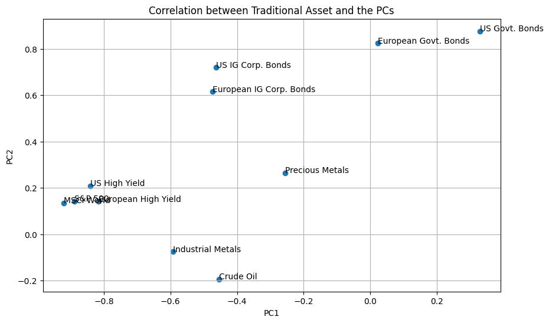

```python
plt.figure(figsize=(10, 6))
plt.scatter(correlation_TAM_4w.iloc[0:11]['PC1'], correlation_TAM_4w.iloc[0:11]['PC2'])

for i, txt in enumerate(correlation_TAM_4w.iloc[0:11].index):
    plt.annotate(txt, (correlation_TAM_4w.iloc[0:11]['PC1'].iloc[i], correlation_TAM_4w.iloc[0:11]['PC2'].iloc[i]))

plt.xlabel('PC1')
plt.ylabel('PC2')
plt.title('Correlation between Traditional Asset and the PCs')
plt.grid(True)
plt.show()
```

# Systematic Strategies

### Do the same with the file Systematic Strategies Multi-asset PCA CHANGES=4w.csv

```python
# # Load the data
# SSAM_4w = pd.read_csv('Copie de Systematic Strategies_Multi-asset PCA_CHANGES=4w.csv',index_col=0)
# SSAM_4w.fillna(0, inplace=True)
# # Perform PCA
# SSAM_4w_normalized = (SSAM_4w - SSAM_4w.mean()) / SSAM_4w.std()
# pca_SSAM_model = PCA(n_components=2)
# pca_SSAM = pca_SSAM_model.fit_transform(SSAM_4w_normalized)
# returns = pd.DataFrame(pca_model.transform(MA_pca_changes_normalised), columns=[f'PC{i+1}' for i in range(pca_model.n_components_)])
```

### Compute the correlation of each assets with PC1 and PC2

```python
# Compute the correlation of each asset with PC1 and PC2
SSAM_4w = pd.read_csv('Copie de Systematic Strategies_Multi-asset PCA_CHANGES=4w.csv',index_col=0)
SSAM_4w.fillna(0, inplace=True)
SSAM_4w_normalized = (SSAM_4w - SSAM_4w.mean()) / SSAM_4w.std()
SSAM_4w_normalized = SSAM_4w_normalized.reset_index(drop=True)
concat = pd.concat([SSAM_4w_normalized,returns_PCA],axis=1)
focus_cols = ['PC1', 'PC2']

correlation_SSAM_4w= concat.corr().filter(focus_cols).drop(focus_cols)
```

```python
print("Correlation between Systematic Strategies Multi Asset and the PCs:\n")
correlation_SSAM_4w[0:16].style.format(formatter='{:+.4f}').applymap(func=format_colour)
```

```
Correlation between Systematic Strategies Multi Asset and the PCs:
```

|  | PC1 | PC2 |
| --- | --- | --- |
| Global Quality Income vs. Index | +0.5803 | -0.0085 |
| Global Equity Machine Learning | -0.1116 | +0.0196 |
| European Value vs. Index | -0.6076 | -0.1091 |
| Commodity Congestion | -0.0977 | +0.0396 |
| Multi-asset Trend | +0.3948 | -0.0504 |
| Repo Carry | -0.2582 | +0.0579 |
| Long Rates Vol. | +0.2752 | -0.0936 |
| Tail Hedge -SDV | +0.2814 | +0.2444 |
| Tail Hedge - SCV | +0.0571 | +0.1030 |
| Tail Hedge - Dynamic Put Ratio | +0.4330 | -0.0482 |
| Put Spread | +0.8593 | -0.1471 |
| Intraday Trend Following | +0.4333 | +0.0860 |
| Strong vs. Weak Balance Sheets | +0.4665 | +0.0533 |
| FX Carry | -0.6061 | -0.1749 |
| FX Value | +0.0907 | +0.1320 |
| Short Weekly Tail Puts | -0.0163 | +0.0798 |

### Make a scatter plot of the previous DataFrame displaying also the name of the points

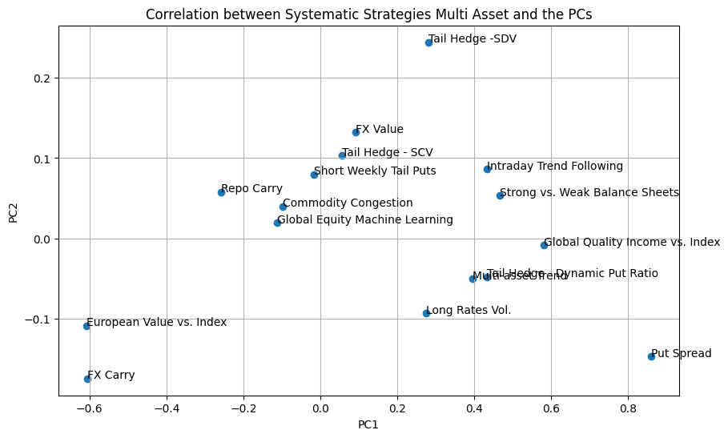

```python
plt.figure(figsize=(10, 6))
plt.scatter(correlation_SSAM_4w[0:16]['PC1'], correlation_SSAM_4w[0:16]['PC2'])

for i, txt in enumerate(correlation_SSAM_4w[0:16].index):
    plt.annotate(txt, (correlation_SSAM_4w[0:16]['PC1'].iloc[i], correlation_SSAM_4w[0:16]['PC2'].iloc[i]))

plt.xlabel('PC1')
plt.ylabel('PC2')
plt.title('Correlation between Systematic Strategies Multi Asset and the PCs')
plt.grid(True)
plt.show()
```

# Portfolio Optimization

### load equity factor performance data.csv

### it displays the value of funds based on traditional trading factors

```python
import warnings
warnings.simplefilter(action='ignore', category=FutureWarning)
import cvxpy as cp
```

```python
df_ef = pd.read_csv('Copie de equity_factor_performance_data.csv', index_col=0, parse_dates=True)
```

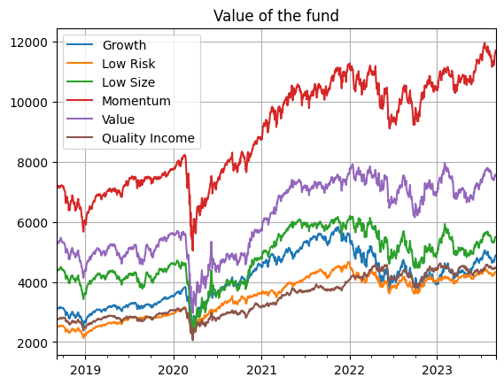

```python
df_ef.plot()
plt.title('Value of the fund')
plt.grid(True)
```

### compute the returns of the fund

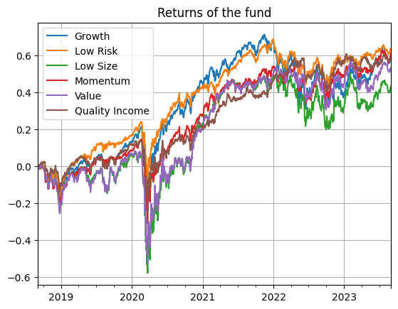

```python
df_ef_returns = df_ef.pct_change()
df_ef_returns.cumsum().plot()
plt.title('Returns of the fund')
plt.grid(True)
```

### construct the min variance portfolio, display its cumsum return

```python
def min_variance(expected_return,df_ef):
  n = len(df_ef.columns)
  R = (df_ef.iloc[-1] - df_ef.iloc[0]) / df_ef.iloc[0]
  COV = df_ef.pct_change().cov()
  G = np.vstack([-np.identity(n),-R.values.reshape(1,n)])
  h = np.vstack([np.zeros((n,1)),-np.ones((1,1))*expected_return])
  A = np.ones((1,n))
  b = np.ones(1)
  x = cp.Variable(n)
  prob = cp.Problem(cp.Minimize(cp.quad_form(x, COV)),
                  [G @ x <= h.flatten(),
                    A @ x == b])
  prob.solve()
  X= pd.Series(x.value,R.index)
  C = pd.Series(np.diag(COV),R.index)
  Y = pd.concat([R,C.apply(np.sqrt)*10000,X],axis=1)
  Y.columns = ['Return', 'Volatility', 'Weight']
  return Y
```

```python
df_min_variance = min_variance(0,df_ef)
df_min_variance.style.format(formatter='{:+.4f}').applymap(func=format_colour)
```

|  | Return | Volatility | Weight |
| --- | --- | --- | --- |
| Growth | +0.5519 | +159.8837 | +0.0000 |
| Low Risk | +0.7125 | +120.7954 | +0.4424 |
| Low Size | +0.2369 | +184.0437 | -0.0000 |
| Momentum | +0.6195 | +138.7744 | +0.0000 |
| Value | +0.4105 | +170.0034 | -0.0000 |
| Quality Income | +0.6197 | +118.3051 | +0.5576 |

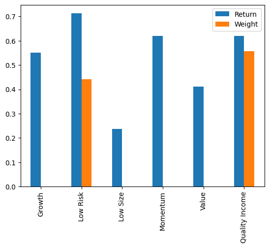

```python
df_min_variance[['Return','Weight']].plot(kind='bar')
```

```python
df_min_variance.corr().style.format(formatter='{:+.4f}').applymap(func=format_colour)
```

|  | Return | Volatility | Weight |
| --- | --- | --- | --- |
| Return | +1.0000 | -0.9162 | +0.6007 |
| Volatility | -0.9162 | +1.0000 | -0.8321 |
| Weight | +0.6007 | -0.8321 | +1.0000 |

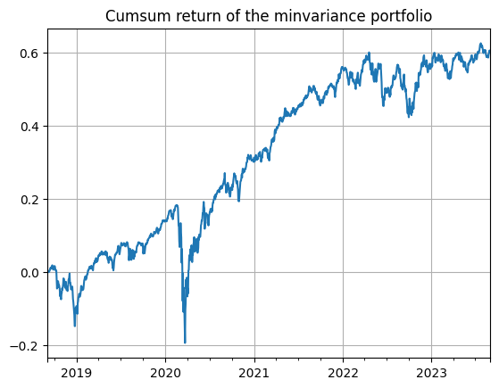

```python
weighted_returns = df_ef_returns * df_min_variance['Weight']
weighted_returns['weighted_returns'] = weighted_returns.sum(axis = 1)
weighted_returns['weighted_returns'].cumsum().plot()
plt.title('Cumsum return of the minvariance portfolio')
plt.grid(True)
```

### At the begining of each month construct a portfolio using

– expected return : past month performance  
– long only  
– total allocation 1  
– cannot trade more than 0.05 per factor  
– each factor cannot be allocated more than 0.25  
– total trading cannot be more than 0.15

```python
df_ef_returns['Month'] = df_ef_returns.index.month
df_ef_returns['Year']= df_ef_returns.index.year
df_grouped = df_ef_returns.groupby(['Year', 'Month'])
```

```python
df_grouped = df_grouped.aggregate(np.sum)
df_grouped
```

| Year | Month | Growth | Low Risk | Low Size | Momentum | Value | Quality Income |
| --- | --- | --- | --- | --- | --- | --- | --- |
| 2018 | 9 | -0.003174 | 0.006940 | -0.007180 | -0.004618 | -0.009523 | 0.015331 |
|  | 10 | -0.082997 | -0.071027 | -0.076960 | -0.084675 | -0.079548 | -0.067813 |
|  | 11 | 0.026296 | 0.039449 | 0.022305 | 0.013297 | 0.020864 | 0.047386 |
|  | 12 | -0.083148 | -0.075360 | -0.135100 | -0.091374 | -0.126852 | -0.084854 |
| 2019 | 1 | 0.100038 | 0.070698 | 0.117782 | 0.087165 | 0.120849 | 0.069699 |
| ... | ... | ... | ... | ... | ... | ... | ... |
| 2023 | 5 | 0.046241 | -0.033817 | -0.026734 | -0.014941 | -0.035955 | -0.065422 |
|  | 6 | 0.064398 | 0.059199 | 0.087519 | 0.082039 | 0.090519 | 0.039554 |
|  | 7 | 0.046318 | 0.002689 | 0.056766 | 0.023212 | 0.058659 | 0.043971 |
|  | 8 | -0.031023 | -0.010010 | -0.035815 | -0.016500 | -0.035550 | -0.026686 |
|  | 9 | 0.006650 | 0.002253 | 0.005105 | 0.005919 | 0.006534 | -0.000553 |

61 rows × 6 columns

```python
def calculate_portfolio_return(weights, returns):
    return cp.matmul(returns, weights)

portfolio_weights = []
weights = [0,0,0,0,0,0]
portfolio_weights.append(weights)
for i in range(1,len(df_grouped)):
    prev_weights = weights
    returns = df_grouped.iloc[i-1].values
    num_assets = len(df_grouped.iloc[i])

    weights = cp.Variable(num_assets)
    trade = prev_weights - weights
    constraints = [cp.sum(weights) == 1,
                   weights >= 0,
                   weights <= 0.25,
                   cp.abs(trade) <= 0.05,
                   cp.sum(cp.abs(trade)) <= 0.15]

    objective = cp.Maximize(calculate_portfolio_return(weights, returns))

    # Define the problem and solve
    prob = cp.Problem(objective, constraints)
    #print(prob)
    result = prob.solve()
    #print(prob.status)
    # Get the optimal weights
    optimal_weights = weights.value
    portfolio_weights.append(optimal_weights)
```

```python
portfolio_weights.pop(1)
portfolio_weights.insert(1,[0,0,0,0,0])
```

```python
df_portfolio_weights = pd.DataFrame(portfolio_weights)
df_portfolio_weights.columns = ['Growth','Low Risk','Low Size','Momentum','Value','Quality Income']
```

```python
df_portfolio_weights
```

|  | Growth | Low Risk | Low Size | Momentum | Value | Quality Income |
| --- | --- | --- | --- | --- | --- | --- |
| 0 | 0.000000e+00 | 0.000000e+00 | 0.000000e+00 | 0.000000e+00 | 0.000000e+00 | 0.000000e+00 |
| 1 | 0.000000e+00 | 0.000000e+00 | 0.000000e+00 | 0.000000e+00 | 0.000000e+00 | NaN |
| 2 | 6.116958e-08 | 2.500000e-01 | 2.500000e-01 | 4.916946e-08 | 2.499999e-01 | 2.500000e-01 |
| 3 | 2.500000e-01 | 2.500000e-01 | 2.500000e-01 | 5.864270e-10 | 1.053160e-08 | 2.500000e-01 |
| 4 | 2.500000e-01 | 2.500000e-01 | 2.105067e-09 | 2.500000e-01 | 1.032799e-09 | 2.500000e-01 |
| ... | ... | ... | ... | ... | ... | ... |
| 56 | 3.072648e-08 | 2.500000e-01 | 4.989694e-08 | 2.500000e-01 | 2.499999e-01 | 2.500000e-01 |
| 57 | 2.500000e-01 | 2.500000e-01 | 2.500000e-01 | 2.500000e-01 | 2.715304e-08 | 8.971899e-10 |
| 58 | 2.500000e-01 | 7.690441e-10 | 2.500000e-01 | 2.500000e-01 | 2.500000e-01 | 1.775632e-10 |
| 59 | 2.500000e-01 | 3.812974e-09 | 2.500000e-01 | 3.118331e-09 | 2.500000e-01 | 2.500000e-01 |
| 60 | 2.500000e-01 | 2.500000e-01 | 9.325196e-10 | 2.500000e-01 | 9.622754e-10 | 2.500000e-01 |

61 rows × 6 columns

```python
monthly_returns = (df_portfolio_weights * df_grouped.reset_index()).sum(axis=1)
```

### Display the PnL

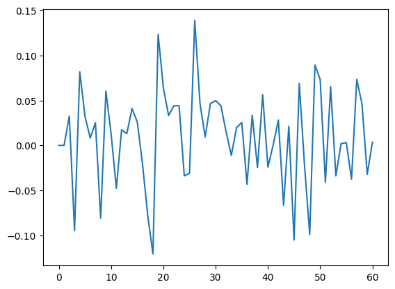

```python
monthly_returns = monthly_returns[~np.isnan(monthly_returns)]
plt.plot(monthly_returns)
```

```python
print(f'Meilleur mois : {100*max(monthly_returns):.4f}%')
print(f'Pire mois : {100*min(monthly_returns):.4f}%')
print(f'Mois moyen : {100*(monthly_returns.mean()):.4f}%')
print(f'Nombre de mois: {len(monthly_returns)}')
print(f'Pnl Total: {100*(monthly_returns.cumsum().iloc[-1]):.4f}%')
```

```
Meilleur mois : 13.8803%
Pire mois : -12.0579%
Mois moyen : 0.9384%
Nombre de mois: 61
Pnl Total: 57.2438%
```

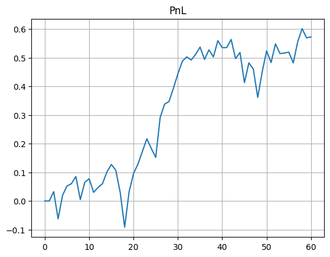

```python
plt.plot(monthly_returns.cumsum())
plt.title('PnL')
plt.grid(True)
```

### Do the same monthly optimization but this time you can get short and the GMV must be 1

```python
portfolio_GMV_weights = []
weights = [0,0,0,0,0,0]
portfolio_GMV_weights.append(weights)
for i in range(1,len(df_grouped)):
    prev_weights = weights
    returns = df_grouped.iloc[i-1].values
    num_assets = len(df_grouped.iloc[i])

    weights = cp.Variable(num_assets)

    trade = prev_weights - weights

    constraints = [cp.norm1(weights) <=  1, # GMV is 1
                   cp.sum(weights) == 0,  # Total allocation = 1
                   weights >= -1, # Allow short
                   cp.abs(weights) <= 0.25, # each factor cannot be allocated more than 0.25
                   cp.abs(trade) <= 0.05,
                   cp.sum(cp.abs(trade)) <= 0.15
                   ]

    objective = cp.Maximize(calculate_portfolio_return(weights, returns))

    # Define the problem and solve
    prob = cp.Problem(objective, constraints)
    result = prob.solve()

    # Get the optimal weights
    optimal_weights = weights.value

    portfolio_GMV_weights.append(optimal_weights)
```

```python
portfolio_GMV_weights.pop(1)
portfolio_GMV_weights.insert(1,[0,0,0,0,0])
```

```python
df_portfolio_GMV_weights = pd.DataFrame(portfolio_GMV_weights)
df_portfolio_GMV_weights.columns = ['Growth','Low Risk','Low Size','Momentum','Value','Quality Income']
```

```python
df_portfolio_GMV_weights
```

|  | Growth | Low Risk | Low Size | Momentum | Value | Quality Income |
| --- | --- | --- | --- | --- | --- | --- |
| 0 | 0.000000e+00 | 0.000000e+00 | 0.000000e+00 | 0.000000e+00 | 0.000000e+00 | 0.000000e+00 |
| 1 | 0.000000e+00 | 0.000000e+00 | 0.000000e+00 | 0.000000e+00 | 0.000000e+00 | NaN |
| 2 | -2.500000e-01 | 2.500000e-01 | 1.193051e-09 | -2.500000e-01 | -5.611548e-09 | 2.500000e-01 |
| 3 | -1.178428e-10 | 2.500000e-01 | -5.906269e-10 | -2.500000e-01 | -2.500000e-01 | 2.500000e-01 |
| 4 | 2.499999e-01 | 2.500000e-01 | -2.500000e-01 | 7.676238e-09 | -2.500000e-01 | 7.244991e-08 |
| ... | ... | ... | ... | ... | ... | ... |
| 56 | -2.500000e-01 | 2.500000e-01 | -2.500000e-01 | -2.637242e-11 | -6.941529e-10 | 2.500000e-01 |
| 57 | 2.500000e-01 | -4.600836e-10 | 3.795076e-11 | 2.500000e-01 | -2.500000e-01 | -2.500000e-01 |
| 58 | -6.378858e-09 | -2.500000e-01 | 2.500000e-01 | 3.732377e-09 | 2.500000e-01 | -2.500000e-01 |
| 59 | 9.497845e-10 | -2.500000e-01 | 2.500000e-01 | -2.500000e-01 | 2.500000e-01 | 4.571996e-10 |
| 60 | -1.381352e-08 | 2.500000e-01 | -2.500000e-01 | 2.500000e-01 | -2.500000e-01 | 1.727948e-10 |

61 rows × 6 columns

```python
monthly_returns_GMV = (df_portfolio_GMV_weights * df_grouped.reset_index()).sum(axis=1)
```

```python
monthly_returns_GMV
```

```
0     0.000000
1     0.000000
2     0.011810
3     0.014503
4    -0.016974
        ...
56   -0.029686
57    0.004091
58    0.017192
59   -0.011214
60   -0.000867
Length: 61, dtype: float64
```

```python
print(f'Meilleur mois : {100*max(monthly_returns_GMV):.4f}%')
print(f'Pire mois : {100*min(monthly_returns_GMV):.4f}%')
print(f'Mois moyen : {100*(monthly_returns_GMV.mean()):.4f}%')
print(f'Nombre de mois: {len(monthly_returns_GMV)}')
print(f'Pnl Total: {100*(monthly_returns_GMV.cumsum().iloc[-1]):.4f}%')
```

```
Meilleur mois : 8.9246%
Pire mois : -5.7506%
Mois moyen : -0.0919%
Nombre de mois: 61
Pnl Total: -5.6038%
```

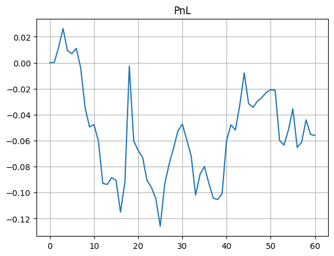

```python
plt.plot(monthly_returns_GMV.cumsum())
plt.title('PnL')
plt.grid(True)
```